# Copernicus Marine Toolbox API

Author

Carlo Zampieri

Published

May 28, 2026

This document will give you a brief introduction on the [Copernicus Marine Toolbox](https://help.marine.copernicus.eu/en/collections/9080063-copernicus-marine-toolbox), which is a Python package to browse and download products from the Copernicus Marine Data Store.

**Important**

The Copernicus Marine Toolbox can be used from the terminal or as a Python module. This document just give an introduction on how to run the toolbox functions in Python, but it does not explain how to get or use Python itself. For more information on Python visit the [official webpage](https://www.python.org/), or [this page](https://posit.co/blog/three-ways-to-program-in-python-with-rstudio) to know how to use Python within your RStudio environment.

## Installation

This tool is compatible with Windows, MacOS and Linux running Python v3.10 to v3.13.

There are several ways to install the toolbox in your computer. Here we will see only the one using `pip`, but if you prefer another way, you can check the [complete installation tutorial](https://help.marine.copernicus.eu/en/articles/7970514-copernicus-marine-toolbox-installation).

Type the following line in your terminal:

```bash
python -m pip install copernicusmarine
```

To make sure the toolbox has been successfully installed, execute this line in your terminal:

```bash
copernicusmarine --version
```

or these commands in your Python environment:

```python
import copernicusmarine
copernicusmarine.__version__
```

## Credentials configuration

As for downloading through the website, you need to login in your personal account. You can do that easily by using the `login` command in Python:

```python
import copernicusmarine
copernicusmarine.login(
  username="youruserid",
  password="yourpassword")
```

**Note**

**You need to login just once!**

## Explore catalogue and metadata

The function `describe` allows to explore the CMEMS catalogue and the metadata of the available products. For example:

```python
import copernicusmarine
copernicusmarine.describe(
  product_id="MEDSEA_MULTIYEAR_BGC_006_008",
  disable_progress_bar=True
  )
```

```
CopernicusMarineCatalogue(products=[CopernicusMarineProduct(title='Mediterranean Sea Biogeochemistry Reanalysis', product_id='MEDSEA_MULTIYEAR_BGC_006_008', thumbnail_url='https://mdl-metadata.s3.waw3-1.cloudferro.com/metadata/thumbnails/MEDSEA_MULTIYEAR_BGC_006_008.jpg', description='The Mediterran…
```

As you can see the output is a bit messy and you might prefer to use the Copernicus Marine Data Store webpage to explore the catalogue more easily.

If you want to know more on the function `describe` and its usage, visit [this page](https://help.marine.copernicus.eu/en/articles/8286798-copernicus-marine-toolbox-api-explore-the-catalogue-and-metadata).

## Subset and download

The web interface for downloading data from the Copernicus Marine Data Store limits you at maximum 1GB files. To bypass this limit you can split the data you need in smaller chunks (for example by time or space) or use the Copernicus Marine Toolbox! The function `subset` allows you to subset and download the data you need without any size limit.

For example, if I want to download the daily surface temperature of 2024 in the northern Adriatic Sea from the Mediterranean Sea Physics Reanalysis product, I will execute the following code:

```python
import copernicusmarine
copernicusmarine.subset(
  dataset_id = "cmems_mod_med_phy-temp_my_4.2km_P1D-m",
  variables = ["thetao"],
  minimum_longitude = 12,
  maximum_longitude = 15.5,
  minimum_latitude = 43.5,
  maximum_latitude = 46,
  start_datetime="2024-01-01T00:00:00",
  end_datetime="2024-12-31T00:00:00",
  minimum_depth=1.0182366371154785,
  maximum_depth=1.0182366371154785,
  output_directory = "C:Users/User/Download/",
  output_filename = "nadr_sst_daily_2024.nc",
  force_download = True
)
```

**Note**

An easier way to know how to fill the function arguments is to select the dataset, variables, spatial and temporal extent in the data store webpage and then click on “Automate”. A pop-up window will show you how to code the data request.

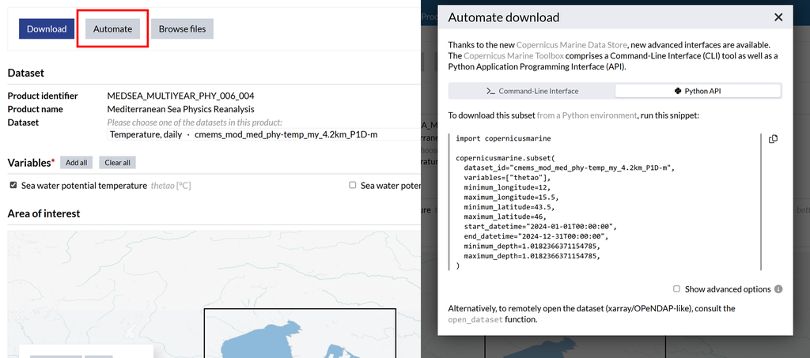